# assignment1

Vincent Tran

2024-09-04

# 1. Course final grade:

30% of the final grade will come from the final exam. Two midterms will make up 20%. Two projects make up 10%. Assignments make up 15%. Labs make up 10% and quizzes make up the last 15%. A is 90%+, B is 80s, C is 60s and 70s, D is 50s, and F is < 50%.

# 2. Biologist coplot:

A biologist wants to make a coplot of LENGTH Vs WEIGHT given RIVER*SPECIES for fish caught in the Tennessee river and recorded in the DDT.csv data set, so that each point is colored according to the variable MILE which is treated as a factor (Qualitative variable).

## (a) Make the coplot as the biologist required

```r
ddt = read.csv("..//..//LAB1//ddt.csv")
head(ddt)
```

```
##   RIVER MILE  SPECIES LENGTH WEIGHT DDT
## 1   FCM    5 CCATFISH   42.5    732  10
## 2   FCM    5 CCATFISH   44.0    795  16
## 3   FCM    5 CCATFISH   41.5    547  23
## 4   FCM    5 CCATFISH   39.0    465  21
## 5   FCM    5 CCATFISH   50.5   1252  50
## 6   FCM    5 CCATFISH   52.0   1255 150
```

```r
m=with(ddt, as.numeric(factor(MILE))) #A
length(unique(m)) #B
```

```
## [1] 17
```

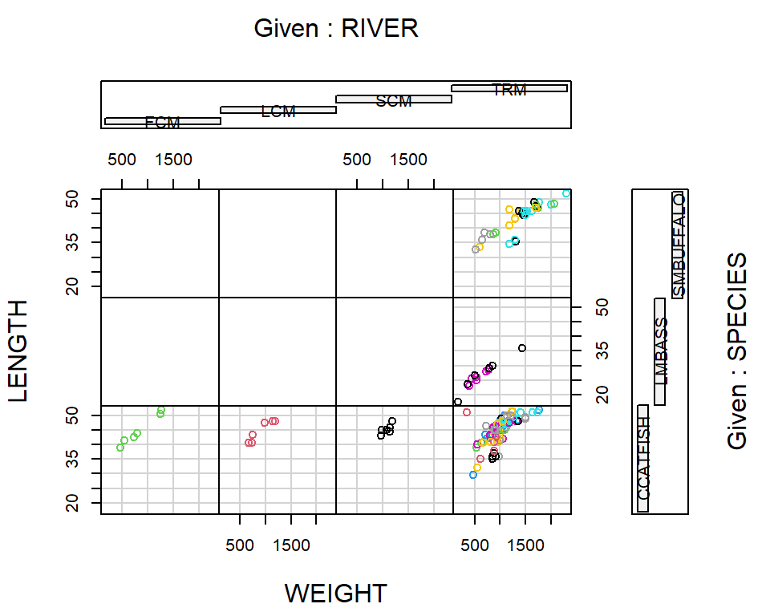

```r
coplot(LENGTH~WEIGHT|RIVER*SPECIES, data=ddt, col=m)
```

## (b) Interpret the lower left three conditional plots.

There are about the same number of catfish in rivers FCM, LCM, and SCM. They are also roughly of the same length and weight.

## (c) What does line A do?

Creates a vector of elements under the MILE column and stores the vector in m. Elements of MILE are sorted in ascending order by factor as levels.

## (d) What does line B do?

the unique function returns a set vector and length gets the number of elements in that vector, thus returning the number of unique mile in m.

## (e) Why are the top six plots empty?

There are no lmbass or smbuffalo in the FCM, LCM, or SCM rivers within the data set.

```r
with(ddt, ddt[(SPECIES == "LMBASS" | SPECIES == "SMBUFFALO") & (RIVER == "FCM" | RIVER == "LCM" | RIVER == "SCM"), ])
```

```
## [1] RIVER   MILE    SPECIES LENGTH  WEIGHT  DDT
## <0 rows> (or 0-length row.names)
```

## (f) What is the mean value of DDT found in the sample of CCATFISH caught in the FCM river?

```r
mean(subset(ddt,RIVER=="FCM" & SPECIES=="CCATFISH",)$DDT)
```

```
## [1] 45
```

# 3. MS 1.14 - pg 8: Classify each variable as quantitative or qualitative.

1. Length of maximum span (feet): quantitative
2. Number of vehicle lanes: quantitative
3. Toll bridge (yes or no): qualitative.
4. Average daily traffic: quantitative
5. Condition of deck (good, fair, or poor): qualitative.
6. Bypass or detour length (miles): quantitative
7. Route type (interstate, U.S., state, county, or city): qualitative.

# 4. MS page 12,13

## (a) names of the four random sampling designs

1. Simple random sampling
2. stratified random sampling
3. cluster sampling
4. Systematic sampling

## (b) brief descriptions

1. all fixed sample sizes in a population has an equal chance of being selected
2. population is split up into two or more groups called strata
3. selecting groups from the population then looking at all within the groups
4. selecting every kth experimental unit from a list of experimental units

# 5. MS 1.15 - pg 15: MTBE sampling

```r
mtbe=read.csv("MTBE.csv", header=TRUE) # You will need to change the address
head(mtbe) # First six lines
```

```
##     pH SpConduct DissOxy RoadsPct IndPct UrbanPct DevPct WellClass Aquifier
## 1 7.87     290.0    0.58     1.34      0    17.77  17.77   Private  Bedrock
## 2 8.63     225.9    0.84     0.72      0    10.43  10.43   Private  Bedrock
## 3 7.11     157.4    8.37     1.92      0    29.62  50.01   Private  Bedrock
## 4 7.98     723.6    0.41     2.76      0    41.65  41.65   Private  Bedrock
## 5 7.88     148.7    1.44     3.51      0    51.21  51.21   Private  Bedrock
## 6 8.36     198.2    0.18     1.48      0    22.49  29.19   Private  Bedrock
##     Depth SafeYld Distance MTBE.Detect MTBE.Level HouseDen PopDen
## 1  60.960      NA  2386.29 Below Limit        0.2   131.16  43.19
## 2  36.576      NA  3667.69 Below Limit        0.2    47.69  24.52
## 3 152.400      NA  2324.15 Below Limit        0.2    85.16  33.32
## 4      NA      NA   788.88 Below Limit        0.2   134.77  46.61
## 5  91.440      NA  1337.88 Below Limit        0.2   198.54  78.58
## 6 115.824      NA  2396.74 Below Limit        0.2   206.73  59.47
```

```r
dim(mtbe) # rows and columns
```

```
## [1] 223  16
```

```r
ind=sample(1:223,5,replace=FALSE) # random indices
mtbe[ind,]
```

```
##       pH SpConduct DissOxy RoadsPct IndPct UrbanPct DevPct WellClass  Aquifier
## 218 7.69     400.8    1.48     2.52  17.61    23.11  24.88    Public   Bedrock
## 161 6.15     291.4    8.14     3.16  10.80    41.78  52.06    Public Unconsoli
## 84  5.66     473.2    4.98     1.00   0.00    15.28  15.57   Private   Bedrock
## 192 7.40     418.3    7.33     2.26   0.00    23.68  32.55    Public   Bedrock
## 51  8.32     240.8    0.93     1.87   0.00    35.02  35.02   Private   Bedrock
##        Depth  SafeYld Distance MTBE.Detect MTBE.Level HouseDen PopDen
## 218       NA       NA   418.25 Below Limit       0.20   183.11  58.01
## 161   7.9248 75.70023   929.21 Below Limit       0.20    93.88  30.29
## 84   51.8160       NA  2694.44 Below Limit       0.20   138.05  43.92
## 192 132.5880 22.71007  4156.63      Detect       4.34   178.29  52.88
## 51  137.1600       NA  3438.30 Below Limit       0.20   245.17  75.50
```

## (a)

### (i) Remove all the rows in mtbe that contain one or more NA’s

```r
mtbeo=na.omit(mtbe)
```

### (ii) Now calculate the standard deviation (sd() in R) of the depth of wells which have “Bedrock” as the Aquifier

```r
depth=mtbeo[mtbeo$Aquifier=="Bedrock",]$Depth
sd(depth)
```

```
## [1] 56.45357
```

# 6. MS 1.16 - pg 15:

```r
earthquake = read.csv("EARTHQUAKE.csv")
head(earthquake)
```

```
##   YEAR MONTH DAY HOUR MINUTE MAGNITUDE
## 1 1994     1  17   12     30       6.7
## 2 1994     1  17   12     31       5.5
## 3 1994     1  17   12     32       3.3
## 4 1994     1  17   12     34       4.2
## 5 1994     1  17   12     36       3.8
## 6 1994     1  17   12     37       3.7
```

```r
dim(earthquake)
```

```
## [1] 2929    6
```

```r
random_indices = sample(1:2929, 30, replace=FALSE)
earthquake[random_indices,]
```

```
##      YEAR MONTH DAY HOUR MINUTE MAGNITUDE
## 2047 1994     1  27   21     42       1.7
## 1144 1994     1  22   13     15       2.1
## 2411 1994     2   1    7     13       1.5
## 2396 1994     2   1    2     43       2.0
## 2236 1994     1  29    7     52       2.6
## 2601 1994     2   3    4     52       1.3
## 2810 1994     2   5    2     17       1.5
## 448  1994     1  19   12     46       2.5
## 2321 1994     1  30   15     42       2.5
## 2100 1994     1  28    7     39       1.6
## 731  1994     1  20   16     37       3.0
## 882  1994     1  21    8     42       2.9
## 2456 1994     2   1   18     58       1.9
## 1639 1994     1  25    8     34       1.3
```

[output cut: 16 more lines]

## (a)

### (i) Make the following plot plot(ts(eq$MAG)):

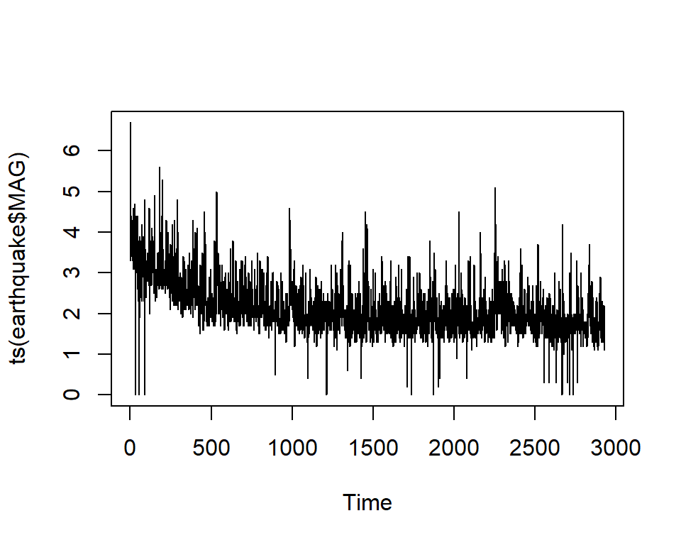

```r
plot(ts(earthquake$MAG))
```

### (ii) Using the entire eq data frame find the median (median()) of the MAGNITUDE variable.

```r
median(earthquake$MAGNITUDE)
```

```
## [1] 2
```

# 7. MS STATISTICS IN ACTION:

## (a) What is the data collection method?

stratified sampling

## (b) What is the population?

all fish in the Tennessee River and its tributaries

## (c) Give the names of all the qualitative variables.

River and species

# 8. MS 2.1 - pg 26 Use pareto()

## a. What type of graph is used to describe the data?

Bar chart

## b. Identify the variable measured for each of the 106 robot designs.

Type of robotic limbs

## c. Use graph to identify the social robot design that is currently used the most.

Robots with legs only

```r
freq=c(15,8,63,20)
RL=c("None","Both","LegsO","WheelsO")
l=rep(RL,freq)
```

## e. Use the results, part d, to construct a Pareto diagram for the data

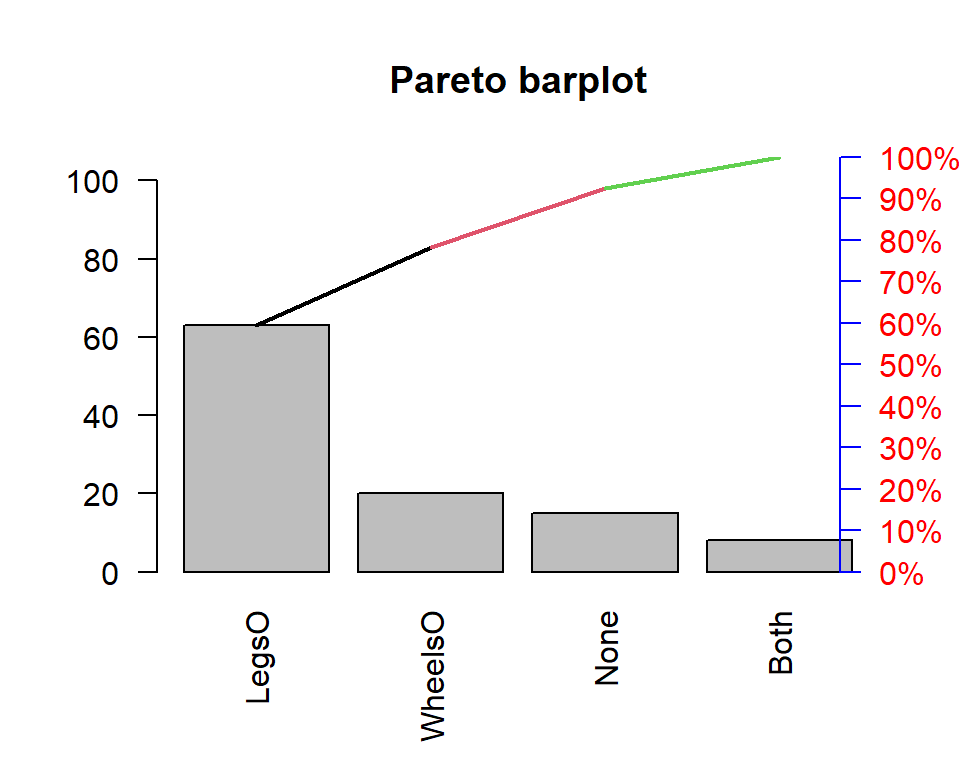

```r
source("pareto.r")
pareto(l)
```

# 9. MS 2.4 - pg 27 - Please use the pareto() function I made.

## a. Construct a pie chart to describe the Microsoft products with security issues. Which product had the lowest proportion of security issues in 2012?

## b. Construct a Pareto diagram to describe the expected repercussions from security issues. Based on the graph, what repercussion would you advise Microsoft to focus on?

# 10. MS 2.10 - pg 28 – Use pie3D() from plotrix package

# 11. MS 2.72 - pg 70

## (a) Fill out the table when constructing the Histogram

## (b) Use the stem() function

## (c) Use R to make the histogram.

# 12. MS 2.73 - pg 70

# 13. MS 2.80 - pg 72

# 14. MS 2.84 - pg 74

# 15. re-create the plot below using ggplot.